# sparklyr analysis

Yue You

2021-07-25

This tutorial introduces tools and concepts to perform data analysis in Spark from R. Spoiler alert: these are the same tools you use with plain R! This is not a mere coincidence; rather, we want data scientists to live in a world where technology is hidden from them, where you can use the R packages you know and love, and they “just work” in Spark! Now, we are not quite there yet, but we are also not that far. Therefore, in this tutorial you learn widely used R packages and practices to perform data analysis—dplyr, ggplot2, formulas, rmarkdown, and so on—which also happen to work in Spark.

Based on [online material](https://therinspark.com/analysis.html).

```r
library(sparklyr)
library(dplyr)
sc <- spark_connect(master = "local", version = "2.3")
```

### Import

Import the data.

```r
taxi_tbl <- spark_read_csv(sc,
                           name = "taxi_data",
                           path ="../data/sample.csv",
                           header = TRUE, delimiter = ",")
```

### Wrangle

Data wrangling uses transformations to understand the data. It is often referred to as the process of transforming data from one “raw” data form into another format with the intent of making it more appropriate for data analysis.

```r
summarize_all(taxi_tbl, mean)
```

```
## # Source: spark<?> [?? x 19]
##   VendorID tpep_pickup_dateti… tpep_dropoff_datet… passenger_count trip_distance
##      <dbl>               <dbl>               <dbl>           <dbl>         <dbl>
## 1     1.53                  NA                  NA            1.70          2.83
## # … with 14 more variables: pickup_longitude <dbl>, pickup_latitude <dbl>,
## #   RatecodeID <dbl>, store_and_fwd_flag <dbl>, dropoff_longitude <dbl>,
## #   dropoff_latitude <dbl>, payment_type <dbl>, fare_amount <dbl>, extra <dbl>,
## #   mta_tax <dbl>, tip_amount <dbl>, tolls_amount <dbl>,
## #   improvement_surcharge <dbl>, total_amount <dbl>
```

Most of the data transformation operations made available by dplyr to work with local DataFrames are also available to use with a Spark connection.

```r
passenger_summary <- taxi_tbl %>%
  group_by(passenger_count) %>%
  summarise(count = n(), fare = mean(fare_amount), dist = mean(trip_distance)) %>%
  filter(count > 200) %>%
  collect
```

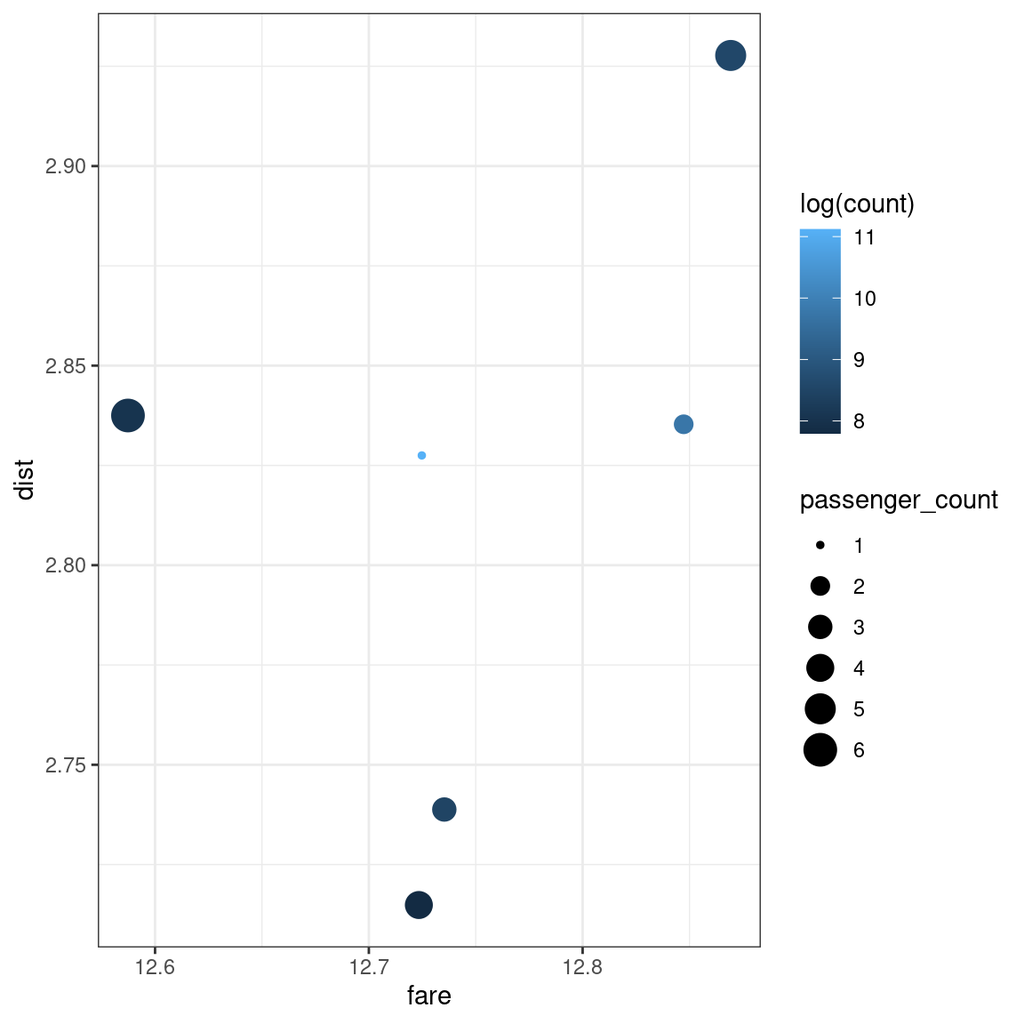

```r
library(ggplot2)
ggplot(passenger_summary) +
  geom_point(aes(x=fare,y=dist,col=log(count),size=passenger_count)) +
  theme_bw()
```

### Correlations

```r
ml_corr(taxi_tbl %>%
          select(total_amount,trip_distance,fare_amount))
```

```
## # A tibble: 3 x 3
##   total_amount trip_distance fare_amount
##          <dbl>         <dbl>       <dbl>
## 1        1             0.899       0.982
## 2        0.899         1           0.900
## 3        0.982         0.900       1
```

```r
#install.packages("corrr")
library(corrr)
correlate(taxi_tbl %>%
          select(total_amount,trip_distance,fare_amount),
          use = "pairwise.complete.obs", method = "pearson")
```

```
## # A tibble: 3 x 4
##   term          total_amount trip_distance fare_amount
##   <chr>                <dbl>         <dbl>       <dbl>
## 1 total_amount        NA             0.899       0.982
## 2 trip_distance        0.899        NA           0.900
## 3 fare_amount          0.982         0.900      NA
```

We can pipe the results to other corrr functions. For example, the shave() function turns all of the duplicated results into NAs. Again, while this feels like standard R code using existing R packages, Spark is being used under the hood to perform the correlation.

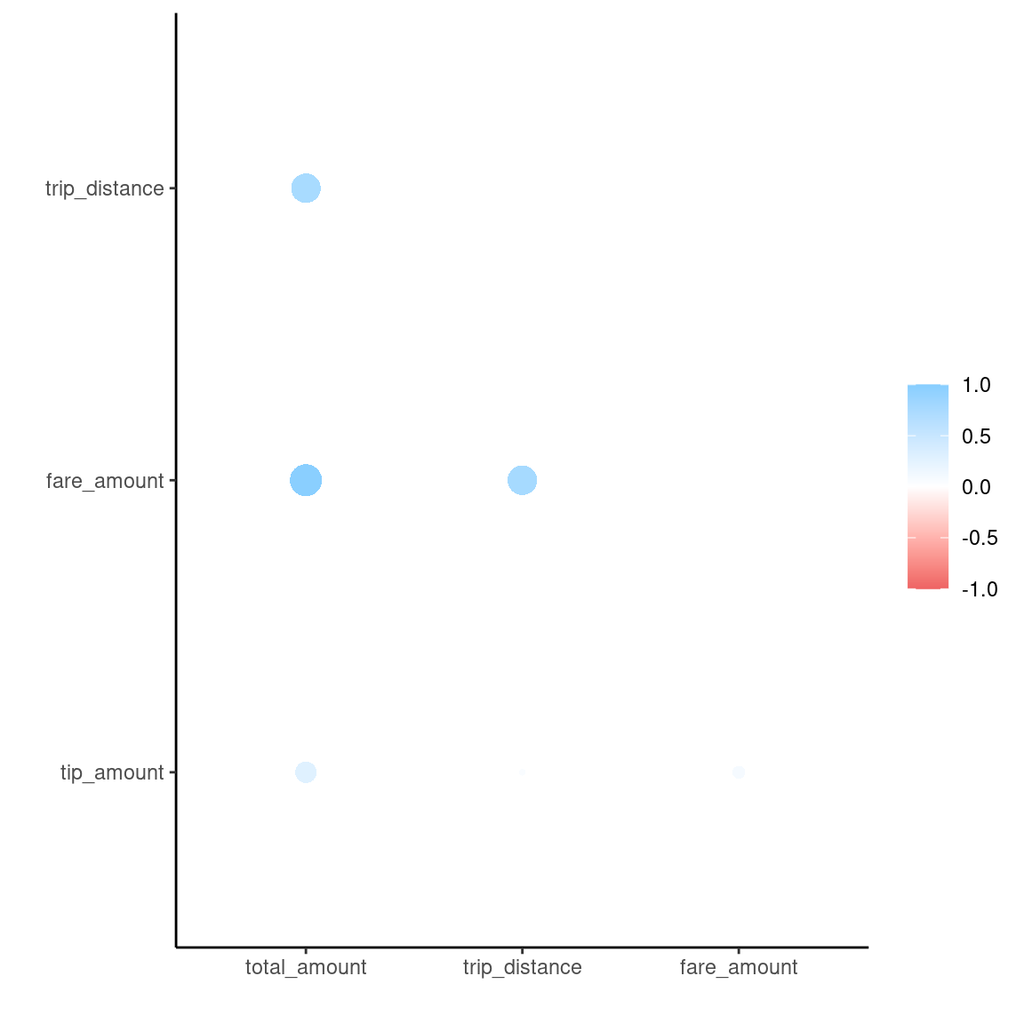

```r
correlate(taxi_tbl %>%
          select(total_amount,trip_distance,fare_amount,tip_amount),
          use = "pairwise.complete.obs", method = "pearson") %>%
  shave() %>%
  rplot()
```

### Machine Learning

You can orchestrate machine learning algorithms in a Spark cluster via the machine learning functions within sparklyr. These functions connect to a set of high-level APIs built on top of DataFrames that help you create and tune machine learning workflows.

Here’s an example where we use ml_linear_regression to fit a linear regression model.

```r
fit <- taxi_tbl %>%
  ml_linear_regression(total_amount ~ tip_amount + passenger_count)
```

For linear regression models produced by Spark, we can use summary() to learn a bit more about the quality of our fit, and the statistical significance of each of our predictors.

```r
summary(fit)
```

```
## Deviance Residuals:
##      Min       1Q   Median       3Q      Max
## -304.363   -4.798   -2.177    2.000  360.874
##
## Coefficients:
##     (Intercept)      tip_amount passenger_count
##      9.61369687      3.59498523      0.06311856
##
## R-Squared: 0.4702
## Root Mean Squared Error: 8.668
```